# 第11回 データを分析する（4）：対応のあるt検定とデータ構造

行動計量学（行動科学分析法入門）

小野原 彩香

令和8年度

## 本日の目標

1. 対応のあるデータと対応のないデータの違いを説明できる
2. 対応のあるt検定を Rで実行し，解釈できる
3. ワイド形式・ロング形式を変換できる（`pivot_longer()` / `pivot_wider()`）
4. **発展**：対応を取るとなぜ検出力が上がるのかを，式で説明できる

## 準備：パッケージの読み込み

この回のコードは，すべて `tidyverse` を読み込んだ状態で動きます。 RStudioを起動したら，**まずこれを実行してください。**

```r
library(tidyverse)
```

> 毎回必要です。読み込まないまま `filter()` や `ggplot()` を使うと， 「関数が見つかりません」というエラーになります。

## 1. 対応のある vs. 対応のないデータ

### 対応のないデータ（独立2標本）→ 第10回で学習済み

- A群と B群が**異なる人**で構成される
- 例：男性グループ vs. 女性グループの試験点数

### 対応のあるデータ（繰り返し測定）

- **同じ人**から2回以上測定した（または対になったペアがある）
- 例：同じ人の**事前**と**事後**の点数
- 例：双子の左右の腕の測定値

### 対応あり vs. なしの判断

| 対応あり | 対応なし |
| --- | --- |
| 同じ人を前後で測定 | 別の人を比較 |
| マッチドペア（年齢・性別を一致させたペア） | 無作為に2群に割り当て |

## 2. 例：介入前後の睡眠時間

```r
# 架空データ：睡眠改善プログラム前後の睡眠時間（時間）
set.seed(42)
n <- 15
sleep_data <- tibble(
  id     = 1:n,
  before = round(rnorm(n, mean = 6.0, sd = 0.8), 1),
  after  = round(before + rnorm(n, mean = 0.8, sd = 0.5), 1)
)
sleep_data
```

| id | before | after |
| --- | --- | --- |
| 1 | 7.1 | 8.2 |
| 2 | 5.5 | 6.2 |
| 3 | 6.3 | 5.8 |
| 4 | 6.5 | 6.1 |
| 5 | 6.3 | 7.8 |
| 6 | 5.9 | 6.5 |
| 7 | 7.2 | 7.1 |
| 8 | 5.9 | 6.6 |
| 9 | 7.6 | 9.0 |
| 10 | 5.9 | 7.6 |

[output cut: 5 more lines]

> **`set.seed(42)` は何をしているか。** `rnorm()` は**毎回ちがう乱数**を返します。そのままでは実行するたびに数値が変わり， 手元の結果と資料の結果が一致しません。 `set.seed()` で乱数の出発点を固定しておくと，**誰がいつ実行しても同じ数値**になります。 カッコの中の数字（ここでは42）は何でもよく，「同じ数字なら同じ結果」という意味だけを持ちます。

> 上のコードを `set.seed(42)` の行から実行すれば，この資料とまったく同じ表が出ます。 違う数値が出た人は，`set.seed()` の行を実行し忘れています。 **第12回の習熟度確認テストでも使うので，ここで覚えてください。**

```r
# 基本統計量
sleep_data |>
  summarise(
    mean_before = mean(before),
    sd_before   = sd(before),
    mean_after  = mean(after),
    sd_after    = sd(after),
    mean_diff   = mean(after - before)
  )
```

| mean_before | sd_before | mean_after | sd_after | mean_diff |
| --- | --- | --- | --- | --- |
| 6.373333 | 0.8163216 | 7 | 1.121224 | 0.6266667 |

## 3. データ構造の変換

### ワイド形式（Wide）

現在の `sleep_data` のような形式：各個人が1行，時点が別の列

```r
sleep_data
```

| id | before | after |
| --- | --- | --- |
| 1 | 7.1 | 8.2 |
| 2 | 5.5 | 6.2 |
| 3 | 6.3 | 5.8 |
| 4 | 6.5 | 6.1 |
| 5 | 6.3 | 7.8 |
| 6 | 5.9 | 6.5 |
| 7 | 7.2 | 7.1 |
| 8 | 5.9 | 6.6 |
| 9 | 7.6 | 9.0 |
| 10 | 5.9 | 7.6 |

[output cut: 5 more lines]

### ロング形式（Long）

分析・グラフ作成でよく使う形式：測定値と時点が別の列

```r
# pivot_longer でワイド → ロングに変換
sleep_long <- sleep_data |>
  pivot_longer(
    cols      = c(before, after),   # 変換する列
    names_to  = "time",             # 時点を入れる新しい列名
    values_to = "sleep"             # 値を入れる新しい列名
  ) |>
  mutate(time = factor(time, levels = c("before", "after"),
                       labels = c("プログラム前", "プログラム後")))
sleep_long
```

| id | time | sleep |
| --- | --- | --- |
| 1 | プログラム前 | 7.1 |
| 1 | プログラム後 | 8.2 |
| 2 | プログラム前 | 5.5 |
| 2 | プログラム後 | 6.2 |
| 3 | プログラム前 | 6.3 |
| 3 | プログラム後 | 5.8 |
| 4 | プログラム前 | 6.5 |
| 4 | プログラム後 | 6.1 |
| 5 | プログラム前 | 6.3 |
| 5 | プログラム後 | 7.8 |

[output cut: 20 more lines]

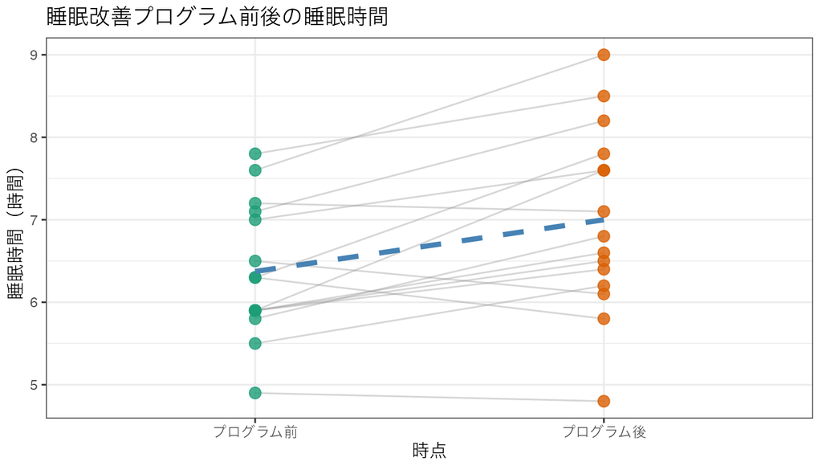

```r
# 可視化（対応あり：同じ人をつなぐ線を引く）
ggplot(sleep_long, aes(x = time, y = sleep, group = id)) +
  geom_line(alpha = 0.4, color = "gray60") +
  geom_point(aes(color = time), size = 3, alpha = 0.8) +
  stat_summary(aes(group = 1), fun = mean, geom = "line",
               linewidth = 1.5, color = "steelblue", linetype = "dashed") +
  scale_color_brewer(palette = "Dark2") +
  labs(title = "睡眠改善プログラム前後の睡眠時間",
       x = "時点", y = "睡眠時間（時間）", color = "時点") +
  theme_bw() +
  theme(legend.position = "none")
```

## 4. 対応のあるt検定の実行

```r
# 方法1：paired = TRUE を指定
t.test(sleep_data$after, sleep_data$before, paired = TRUE)
```

```
##
##  Paired t-test
##
## data:  sleep_data$after and sleep_data$before
## t = 3.6211, df = 14, p-value = 0.00278
## alternative hypothesis: true mean difference is not equal to 0
## 95 percent confidence interval:
##  0.2554933 0.9978400
## sample estimates:
## mean difference
##       0.6266667
```

```r
# 方法2：差分ベクトルを作って1標本t検定として実行（同じ結果）
diff_sleep <- sleep_data$after - sleep_data$before
t.test(diff_sleep, mu = 0)
```

```
##
##  One Sample t-test
##
## data:  diff_sleep
## t = 3.6211, df = 14, p-value = 0.00278
## alternative hypothesis: true mean is not equal to 0
## 95 percent confidence interval:
##  0.2554933 0.9978400
## sample estimates:
## mean of x
## 0.6266667
```

### 結果の読み方

```
    Paired t-test

data:  sleep_data$after and sleep_data$before
t = 3.6211, df = 14, p-value = 0.00278
alternative hypothesis: true mean difference is not equal to 0
95 percent confidence interval:
 0.2554933 0.9978400
sample estimates:
mean difference
      0.6266667
```

| 項目 | 意味 |
| --- | --- |
| `t` | t統計量（差の平均 ÷ 差の標準誤差） |
| `df` | 自由度（$n - 1 = 14$。**$2n$ ではない**） |
| `p-value` | p値（< 0.05 で有意） |
| `95% CI` | **差**の95%信頼区間（0を含まなければ有意） |
| `mean difference` | 差の平均（= after の平均 − before の平均） |

> **第10回の出力と見比べてください。** 独立2標本では各群の平均が2つ出ましたが， 対応ありでは **`mean difference` が1つだけ**です。 分析しているのが「2つの群」ではなく「15個の差」だからです（導出①）。

**導出①**：対応のある$t$検定は，新しい検定ではない**

上の2つのコードが同じ結果を返したことに注目してください。`paired = TRUE` を指定した検定と，差を取ってから1標本の検定をした結果は**まったく同じ**です。偶然ではありません。対応のある$t$検定は，定義からしてそういうものだからです。

各個体 $i$ について，2回の測定の差を作ります。

$$d_i = x_i - y_i \quad (i = 1, \dots,
n)$$

この $d_1, \dots, d_n$ を，ただの $n$ 個のデータとして扱います。「変化がなかった」という帰無仮説は，この差の母平均が0だという主張

$$H_0 : \mu_d = 0$$

に翻訳されます。あとは第10回とまったく同じで，標本平均をその標準誤差で割るだけです。

$$t = \frac{\bar{d}}{SE_{\bar{d}}} =
\frac{\bar{d}}{s_d / \sqrt{n}}$$

**数値で確かめる**：この睡眠データでは $\bar{d} = 0.6267$，$s_d = 0.6703$，$n = 15$ です。$SE = 0.6703/\sqrt{15} = 0.1731$ なので $t = 0.6267/0.1731 = 3.6211$，自由度は $n-1 = 14$，$p = 0.0028$ となります。上の `t.test(..., paired = TRUE)` の出力と一致します。

2つの測定値の対を，1つの差に畳んでしまう。これが「対応を取る」という操作の中身です。$n$ 組の対から $n$ 個の差が作られるので，分析に使うデータの個数は $2n$ ではなく $n$ になります。

**使った数学**：引き算と，第10回の1標本$t$検定。新しい道具は何も要りません。

> **前提も「差」について考えます。** 必要なのは，前後それぞれの値が正規分布することではなく，**差 $d_i$ が正規分布すること**です。 差を1標本として扱っているので，前提も1標本t検定のものがそのまま当てはまります。

## 5. 効果量：Cohenの *d*（対応あり）

対応ありの場合，効果量は**差の平均を，差の標準偏差で割って**求めます。

$$d_z = \frac{\bar{d}}{s_d}$$

```r
d_paired <- mean(diff_sleep) / sd(diff_sleep)
round(d_paired, 2)
```

```
## [1] 0.93
```

$d_z = 0.93$ ですから，第10回の目安（0.2＝小／0.5＝中／0.8＝大）では**大きい効果**です。

> **第10回の *d* とは分母が違います。** 独立2標本では**2群のばらつき**（プールした標準偏差）で割りましたが， 対応ありでは**差のばらつき** $s_d$ で割ります。 差のばらつきは $-2\mathrm{Cov}$ のぶん小さい（導出②）ので， **同じデータでも対応ありの $d$ のほうが大きく出ます。** 実際このデータを独立2標本流に計算すると $d = 0.64$ で，$d_z = 0.93$ とはかなり違います。

> どちらも「Cohenの *d*」と呼ばれるため混同されがちです。 区別するため，対応ありのほうを **$d_z$** と書くことがあります。 **論文で読むときは，分母が何かを確かめてください。**

## 6. 独立t検定との比較

同じデータを誤って「対応なし」で分析すると：

```r
# 対応なし（誤った分析）
t.test(sleep_data$after, sleep_data$before, paired = FALSE)
```

```
##
##  Welch Two Sample t-test
##
## data:  sleep_data$after and sleep_data$before
## t = 1.75, df = 25.587, p-value = 0.09211
## alternative hypothesis: true difference in means is not equal to 0
## 95 percent confidence interval:
##  -0.1099958  1.3633291
## sample estimates:
## mean of x mean of y
##  7.000000  6.373333
```

> `paired = FALSE` にすると，第10回と同じ**Welch法**の独立2標本t検定になります （出力の1行目が `Welch Two Sample t-test` に変わっていることを確認してください）。

**同じデータなのに，結論が変わりました。**

| 分析の仕方 | $t$ | $df$ | $p$ | 判定 |
| --- | --- | --- | --- | --- |
| 対応あり（正しい） | 3.62 | 14 | **0.0028** | 有意 |
| 対応なし（誤り） | 1.75 | 25.59 | 0.0921 | 有意でない |

> 対応のある分析の方が一般的に検出力が高い（個人差を除去できるため）。 データ構造を正しく理解して，適切な分析を選ぶことが重要。

**導出②**：なぜ対応を取ると有意になりやすいのか ―― $-2\mathrm{Cov}$ の効き目**

上の2つの結果を見比べてください。**まったく同じデータ**なのに，対応のある検定では $p = 0.0028$，対応なしでは $p = 0.092$ です。片方は有意，もう片方は有意になりません。何が起きたのでしょうか。

鍵は差の分散です。2つの確率変数の差の分散は，一般に次の式で書けます。

$$\mathrm{Var}[X - Y] = \mathrm{Var}[X] +
\mathrm{Var}[Y] - 2\,\mathrm{Cov}[X, Y]$$

第10回では2群が独立だったので $\mathrm{Cov} = 0$ となり，この第3項が消えていました。だから分散が単純な足し算になったのです。

ところが同じ人を2回測ったデータでは，**よく眠る人は前も後もよく眠ります**。2つの測定は正に相関し，$\mathrm{Cov}[X, Y] > 0$ になります。すると第3項が引き算として効いて，差の分散は足し算より**小さく**なります。

**数値で確かめる**：この睡眠データでは $\mathrm{Var}[\text{前}] = 0.6664$，$\mathrm{Var}[\text{後}] = 1.2571$，$\mathrm{Cov} = 0.7371$（相関 $r = 0.805$）です。

$$0.6664 + 1.2571 - 2 \times 0.7371 =
0.4492$$

実際に `var(after - before)` を計算しても $0.4492$ で，ぴったり一致します。もし2つが独立だったなら $0.6664 + 1.2571 = 1.9235$ で，4倍以上の大きさでした。

標準誤差で比べると，違いは歴然です。

| 分析の仕方 | 分母の $SE$ | $t$ | $p$ |
| --- | --- | --- | --- |
| 対応あり（正しい） | 0.1731 | 3.62 | 0.0028 |
| 対応なし（誤り） | 0.3581 | 1.75 | 0.092 |

分母が $0.483$ 倍に縮むので，$t$ はそのぶん大きくなります。

> **個人差を「除去する」とは，この $-2\mathrm{Cov}$ のことです。** 対応があるのに独立2標本の検定を使うと，せっかくの共分散の情報を捨てることになります。分母が無駄に大きいまま検定するので，本当にある効果を見逃しやすくなります。

**使った数学**：分散の加法性の一般形（共分散の項まで含めたもの）。第10回で「2群が独立なら」と断っていたのは，この項を落とすためでした。

**導出③**：自由度は減る。それでも対応を取るほうが得なのはなぜか**

対応を取ると，代償もあります。自由度が減るのです。

| 分析の仕方 | 使うデータの個数 | 自由度 |
| --- | --- | --- |
| 独立2標本（§6の出力・Welch法） | $n_1 + n_2 = 30$ | $25.59$ |
| 対応あり | $n = 15$（差の個数） | $n - 1 = 14$ |

> 等分散を仮定するStudent法なら，自由度はちょうど $n_1 + n_2 - 2 = 28$ です。 §6では第10回の方針どおりWelch法を使ったので，$25.59$ という小数になっています。

自由度が小さいほど$t$分布の裾は重くなり，有意と判定されるための臨界値は大きくなります。つまり不利です。

それでも対応を取るほうが得なのは，**分母の縮小がこの不利を上回る**からです。臨界値は $2.0571$（自由度25.59）から $2.1448$（自由度14）へ $4.3\%$ 大きくなるだけですが，分母のほうは $0.483$ 倍まで縮みます。$t$ が倍以上になる効果のほうが，はるかに大きいのです。

ただし，これは**相関が正のとき**の話です。式に戻って考えます。

$$\mathrm{Var}[X - Y] = \mathrm{Var}[X] +
\mathrm{Var}[Y] - 2\,\mathrm{Cov}[X, Y]$$

- $\mathrm{Cov} > 0$（正の相関）：第3項が引き算として効き，分散は縮む。**対応を取るほうが得**
- $\mathrm{Cov} = 0$（無相関）：第3項が消え，分散は独立のときと同じ。**自由度が減るぶん損**
- $\mathrm{Cov} < 0$（負の相関）：第3項が足し算になり，分散はかえって膨らむ。**はっきり損**

前後の測定が正に相関するのは，多くの場合そうなりやすいというだけで，保証された性質ではありません。

> **対応を取るかどうかは，データの取り方が決めます。** 同じ個体を2回測ったなら対応あり，別々の個体どうしなら対応なしです。相関の強さを見てから有利なほうを選ぶ，という性質のものではありません。検定の方法は，データを集めた設計によって決まります。

**使った数学**：自由度と$t$分布の臨界値，そして導出②の分散の式。

## 7. pivot_wider：ロング → ワイドの変換

```r
# ロング → ワイドに戻す
sleep_long |>
  pivot_wider(
    id_cols    = id,
    names_from  = time,
    values_from = sleep
  )
```

| id | プログラム前 | プログラム後 |
| --- | --- | --- |
| 1 | 7.1 | 8.2 |
| 2 | 5.5 | 6.2 |
| 3 | 6.3 | 5.8 |
| 4 | 6.5 | 6.1 |
| 5 | 6.3 | 7.8 |
| 6 | 5.9 | 6.5 |
| 7 | 7.2 | 7.1 |
| 8 | 5.9 | 6.6 |
| 9 | 7.6 | 9.0 |
| 10 | 5.9 | 7.6 |

[output cut: 5 more lines]

> **列名が `before` / `after` に戻らないことに注意。** §3で `factor(..., labels = c("プログラム前", "プログラム後"))` とラベルを付け替えたので， `names_from = time` はそのラベルを列名にします。 日本語の列名は `df$プログラム前` のようには書けず， **`df$\`プログラム前`` とバッククォートで囲む**必要があります。 あとで分析に使う列は，**英数字の名前のままにしておくほうが楽です。**

## 演習

### 演習1：データ構造の判断

以下のデータはそれぞれ「対応あり」か「対応なし」か判断してください。

1. 同じ学生が「春学期」と「秋学期」に受けたテストの点数
2. 男子学生20人と女子学生20人の体重を比較
3. 双子（一卵性）の知能指数（IQ）の比較

### 演習2：ワイド→ロング変換

以下のデータを `pivot_longer()` でロング形式に変換してください。

```r
# 架空データ：3名の授業前後の不安度スコア
anxiety_data <- tibble(
  id     = c("A", "B", "C"),
  pre    = c(7, 5, 8),
  post   = c(4, 3, 6)
)
anxiety_data
```

| id | pre | post |
| --- | --- | --- |
| A | 7 | 4 |
| B | 5 | 3 |
| C | 8 | 6 |

```r
anxiety_long <- anxiety_data |>
  pivot_longer(
    cols      = c(pre, post),
    names_to  = "___",
    values_to = "___"
  )
```

### 演習3：対応のあるt検定

演習2のデータ（`anxiety_data`）を使って， 授業前後で不安度スコアが有意に変化したか検定してください。

```r
t.test(anxiety_data$post, anxiety_data$pre, paired = ___)
```

### 演習4：結果の記述

演習3の結果を1〜2文でまとめてください。

## 本日のまとめ

- 対応のあるデータ（反復測定・ペア）には **paired t検定** を使う
- `t.test(..., paired = TRUE)` で実行
- `pivot_longer()` でワイド→ロング形式の変換が簡単にできる
- データ構造を正しく理解することが分析の第一歩

## 宿題・予習

- 演習3〜4を仕上げておく
- 次回は **習熟度確認テスト（第2回）** です
- 第8〜11回の推測統計（相関・カイ二乗・t検定）を総復習しておく